# Voronoi polygons in Python

[figure not shown]

```python
from IPython import display
display.Image(url='https://images.unsplash.com/photo-1577034396763-be129647691b?ixlib=rb-4.0.3&ixid=MnwxMjA3fDB8MHxwaG90by1wYWdlfHx8fGVufDB8fHx8&auto=format&fit=crop&w=1172&q=80',
             embed=True, format='png',
             width=600, height=400)
```

## Introduction

We are revisiting voronoi polygons again. Last time we did them in R. However, our curious, restless mind also wants test them under the fangs of python. But first, what are the uses of Voronoi polygons? Credited to the Ukrainian born academic [George Voronyi](https://sciendo.com/pdf/10.2478/pcr-2018-0009), they are used to show how a specific location within a polygon is closer to the sample point in that polygon than any other sample point. George may have received the glory for this, but its actual use stems way back to the mid 19th Century, when the all famous Jon Snow used them to identify the source of London's cholera outbreak in 1854. By the way, if you this doctor's number, holla me... I need an appointment with him.

Below are some of the uses of [voronoi polygons](https://sciendo.com/pdf/10.2478/pcr-2018-0009).

1. Voronoi’s are used to construct maps of representiveness, for example points experiencing the same precipitation
2. Voronoi diagrams are used in the research of socio-economic phenomena. Polygon’s in their classic form were used to determine transportation accessibility of railway stations and other transportation stops
3. The method was used to analyze spatial patterns of distribution and accessibility of discount stores to determine the accessibility of green areas in certain large cities of Europe
4. Voronoi diagrams have been used to delimit school zones and availability of medical services in an area called Presov, Slovakia
5. In research conducted in the Beijing agglomeration, voronoi’s were used to determine the zone of transit transportation
6. Voronoi polygons were used to delimit maritime zones in the Gulf of Salwa between Saudi Arabia and Qatar

Another name by which voronoi polygons go by is Thiessen polygons, after the American meteorologist Alfred Thiessen. However, since we are not starting an academic war we will just go by their name attributed to the earlier inventor, George Voronoi.

## Loading the datasets

For this voronoi plotting experiment, we will not tread too far from Jon Snow's initial medical purposes. We shall use voronoi polygons to draw voronoi polygons indicating the spatial coverage for a sample of Canadian hospitals. Canada is the second largest country worldwide by the way, so plotting voronois of health centres even just a sample will be an interesting mix. The Canadian shapefile is available from this [link here](https://www12.statcan.gc.ca/census-recensement/2011/geo/bound-limit/files-fichiers/2016/lcd_000b16a_e.zip).

Now, let's first of all load the necessary modules.

```python
# Import the necessary modules
import geopandas as gpd
import pandas as pd
import matplotlib.pyplot as plt
import fiona
from zipfile import ZipFile
import os
import seaborn as sns
from shapely.ops import unary_union
from geovoronoi import voronoi_regions_from_coords # For creating voronoi polygons
import numpy as np
```

Now that you've downloaded the Canadian administrative shapefile, it's time you access it from your directory. Set a path to the shapefile.

```python
# Path to GIS files
path = "E:/documents/gis800_articles/jupyter/python_voronoi"
```

Let's extract the zipped file containing our Canadian shapefiles. We've done this extraction work in python numerous times before. By now it should be a breezer.

```python
# Show the canada shapefile
# First extract the shapefile downloaded from this link-- (https://www12.statcan.gc.ca/census-recensement/2011/geo/bound-limit/files-fichiers/2016/lcd_000b16a_e.zip)
with ZipFile(os.path.join(path, 'canada_files.zip'), 'r') as zObject:
    zObject.extractall(os.path.join(path, 'canada_extracted'))
```

Let's display the Canadian shapefile.

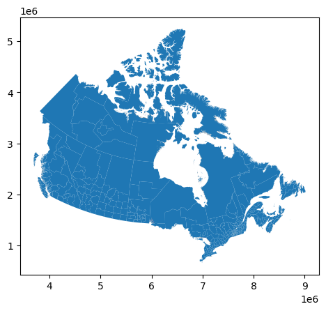

```python
# Now show the Canada shapefile
canadaCensusDivisions = gpd.read_file(os.path.join(path, 'canada_extracted', 'lcd_000b16a_e.shp'))
canadaCensusDivisions.plot()
```

Reading the first few rows of the Canadian shapefile reveals the information below.

```python
# Read the first few rows of canadaCensusDivisions shapefile
canadaCensusDivisions.head()
```

|  | CDUID | CDNAME | CDTYPE | PRUID | PRNAME | geometry |
| --- | --- | --- | --- | --- | --- | --- |
| 0 | 4621 | Division No. 21 | CDR | 46 | Manitoba | POLYGON ((5753862.131 2114062.380, 5752944.009... |
| 1 | 4622 | Division No. 22 | CDR | 46 | Manitoba | POLYGON ((6204057.683 2107140.734, 6204737.266... |
| 2 | 4623 | Division No. 23 | CDR | 46 | Manitoba | MULTIPOLYGON (((6039656.509 2636304.343, 60396... |
| 3 | 4701 | Division No. 1 | CDR | 47 | Saskatchewan | POLYGON ((5422081.934 1612417.386, 5422521.154... |
| 4 | 4702 | Division No. 2 | CDR | 47 | Saskatchewan | POLYGON ((5270212.334 1641442.671, 5270216.591... |

In walking the footsteps of Jon Snow, let's use voronoi polygons to see the spatial distribution of hospitals in Canada. The dataset of Canadian hospitals is [here](https://www150.statcan.gc.ca/n1/en/pub/13-26-0001/2020001/ODHF_v1.1.zip?st=WbSsnZ-r). Extract the file as we did for the shapefile.

```python
# First extract the zipfile
with ZipFile(os.path.join(path, 'ODHF_v1.1.zip'), 'r') as zObject:
    zObject.extractall(os.path.join(path, 'canada_hospitals'))
```

Time to unravel what the hospital dataset has in store for us. It's no surgeon's knife of course, but the errors python hurls out at us are by no means any less hurting. This time round it had do with encoding as displayed in the below cryptic error.

```
UnicodeDecodeError: 'utf-8' codec can't decode byte 0x97 in position 53: invalid start byte
```

After a brief internet search, thanks to the python charmers who have risked their hands with python, inserting the argument `unicode-escape` to the parameter `encoding` let's us live to happily see another day...

```python
# Open and display the Canadian hospital dataset
canadaHospitalsData = pd.read_csv(os.path.join(path, 'canada_hospitals', 'ODHF_v1.1', 'odhf_v1.1.csv'), encoding = 'unicode_escape')
canadaHospitalsData.head()
```

|  | index | facility_name | source_facility_type | odhf_facility_type | provider | unit | street_no | street_name | postal_code | city | province | source_format_str_address | CSDname | CSDuid | Pruid | latitude | longitude |
| --- | --- | --- | --- | --- | --- | --- | --- | --- | --- | --- | --- | --- | --- | --- | --- | --- | --- |
| 0 | 1 | Advanced Facial & Nasal Surgery Centre | other | Ambulatory health care services | Canadian Institute for Health Information | NaN | NaN | NaN | T5M 4G5 | edmonton | ab | NaN | Edmonton | NaN | 48 | NaN | NaN |
| 1 | 10 | Alberta Children's Hospital | pediatric | Hospitals | Public Health Agency of Canada | NaN | 28 | oki dr nw | T3B 6A8 | calgary | ab | 28 Oki Dr NW | Calgary | 4806016.0 | 48 | 51.074582 | -114.148426 |
| 2 | 100 | Devon General Hospital | general | Hospitals | Public Health Agency of Canada | NaN | 101 | erie st s | T9G 1A6 | devon | ab | 101 erie st. s. devon ab t9g 1a6 | Devon | 4811018.0 | 48 | 53.351493 | -113.730785 |
| 3 | 1000 | Kimbelee Place | NaN | Nursing and residential care facilities | Province of British Columbia | NaN | 12935 | 96 ave | V3V 7K6 | surrey | bc | 12935 96th ave surrey bc v3v 7k6 | Surrey | 5915004.0 | 59 | 49.177418 | -122.864118 |
| 4 | 1001 | Kimberley Special Care Home | NaN | Nursing and residential care facilities | Province of British Columbia | NaN | 386 | 2 ave | V1A 2Z6 | kimberley | bc | 386 2 ave kimberley bc v1a 2z6 | Kimberley | 5901028.0 | 59 | 49.689998 | -115.989647 |

```python
# Remove those rows where the Latitude is NaN
canadaHospitalsData2 = canadaHospitalsData.dropna(axis=0, subset=['latitude', 'longitude'], how='any')
canadaHospitalsData2.head(10) # Check for the first 10 rows if there is any with missing Lat-Lon (with NaN values)
```

|  | index | facility_name | source_facility_type | odhf_facility_type | provider | unit | street_no | street_name | postal_code | city | province | source_format_str_address | CSDname | CSDuid | Pruid | latitude | longitude |
| --- | --- | --- | --- | --- | --- | --- | --- | --- | --- | --- | --- | --- | --- | --- | --- | --- | --- |
| 1 | 10 | Alberta Children's Hospital | pediatric | Hospitals | Public Health Agency of Canada | NaN | 28 | oki dr nw | T3B 6A8 | calgary | ab | 28 Oki Dr NW | Calgary | 4806016.0 | 48 | 51.074582 | -114.148426 |
| 2 | 100 | Devon General Hospital | general | Hospitals | Public Health Agency of Canada | NaN | 101 | erie st s | T9G 1A6 | devon | ab | 101 erie st. s. devon ab t9g 1a6 | Devon | 4811018.0 | 48 | 53.351493 | -113.730785 |
| 3 | 1000 | Kimbelee Place | NaN | Nursing and residential care facilities | Province of British Columbia | NaN | 12935 | 96 ave | V3V 7K6 | surrey | bc | 12935 96th ave surrey bc v3v 7k6 | Surrey | 5915004.0 | 59 | 49.177418 | -122.864118 |
| 4 | 1001 | Kimberley Special Care Home | NaN | Nursing and residential care facilities | Province of British Columbia | NaN | 386 | 2 ave | V1A 2Z6 | kimberley | bc | 386 2 ave kimberley bc v1a 2z6 | Kimberley | 5901028.0 | 59 | 49.689998 | -115.989647 |
| 5 | 1002 | Kinetic Energy Health and Wellness Centre | NaN | Ambulatory health care services | Province of British Columbia | NaN | 207-450 | lansdowne street | V2C 1Y4 | kamloops | bc | 207-450 lansdowne street kamloops bc v2c 1y4 | Kamloops | 5933042.0 | 59 | 50.677060 | -120.329500 |
| 6 | 1003 | King Edward House | NaN | Nursing and residential care facilities | Province of British Columbia | NaN | 820 | e king edward ave | V5V 2E4 | vancouver | bc | 820 e king edward ave vancouver bc v5v 2e4 | Vancouver | 5915022.0 | 59 | 49.248353 | -123.087045 |
| 7 | 1004 | Kingfisher Place | NaN | Nursing and residential care facilities | Province of British Columbia | NaN | 4328 | crystal drive | V1T 8V5 | vernon | bc | 4328 crystal drive vernon bc v1t 8v5 | Vernon | 5937014.0 | 59 | 50.276153 | -119.244537 |
| 8 | 1005 | Kinghaven Treatment Centre | NaN | Nursing and residential care facilities | Province of British Columbia | NaN | 31250 | king rd | V2T 6C2 | abbotsford | bc | 31250 king rd abbotsford bc v2t 6c2 | Abbotsford | 5909052.0 | 59 | 49.030749 | -122.358792 |
| 9 | 1006 | Kings House | NaN | Nursing and residential care facilities | Province of British Columbia | NaN | 8512 | 164 st | V4N 1E5 | surrey | bc | 8512 164th st surrey bc v4n 1e5 | Surrey | 5915004.0 | 59 | 49.157599 | -122.767254 |
| 10 | 1007 | Kinsmen Lodge | NaN | Nursing and residential care facilities | Province of British Columbia | NaN | 9650 | 137a st | V3T 4H9 | surrey | bc | 9650 137a st surrey bc v3t 4h9 | Surrey | 5915004.0 | 59 | 49.177735 | -122.841799 |

Good.

But we are still yet to display the voronoi polygons you so badly want to see. We are getting there.

Let's transform the hospital dataset `canadaHospitalsData2` to a geodataframe to view the spatial distribution of hospitals. We shall overlay this hospital's geodataframe over the Canadian map. Doing so will give us a glimpse of how the voronoi output will look like since each hospital will be surrounded by a polygon representing its area coverage. This is another coding spatial exercise we've done several times. Thus we will just glide through it.

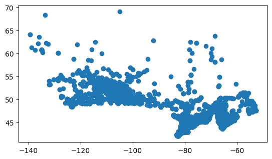

```python
# Convert hospital dataset - canadaHospitalsData2 to a geodataframe - canadaHospitalsGdf
canadaHospitalsGdf = gpd.GeoDataFrame(canadaHospitalsData2,
                                    geometry=gpd.points_from_xy(canadaHospitalsData2['longitude'],
                                                               canadaHospitalsData2['latitude']),
                                    crs='+init=epsg:4326')

canadaHospitalsGdf.plot() # Plot the new geodataframe
```

Before we overlay the hospital's geodataframe `canadaHosptialsGdf` over the Canadian map, let's convert the Canadian shapefile to be in the same Coordinate Reference System (CRS) as that of our hospitals dataset, which is in the well known EPSG:4326 datum.

```python
# Change crs of canadaCensusDivision
canadaCensusDivisions2 = canadaCensusDivisions.to_crs('+init=epsg:4326')
```

Now let's overlay the hospitals geodataframe over the Canadian shapefile.

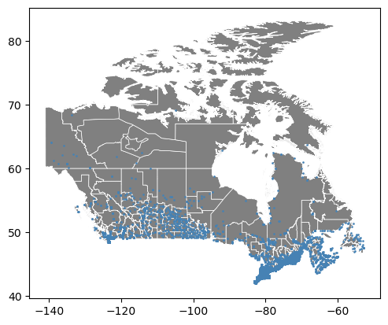

```python
# Overlay the hospitals shapefile over the Canada administrative shapefile
# Setup figure and axis
%matplotlib inline
fig, ax = plt.subplots(1)

# Add the Canadian administrative shapefile on to axis 'ax'
canadaCensusDivisions2.plot(ax=ax, facecolor='grey', edgecolor='white', linewidth=0.5)

# Add a layer of hospital points data on top of axis 'ax'
canadaHospitalsGdf.plot(ax=ax, color='steelblue', markersize=0.8)

# Display the data
plt.show()
```

Because hospitals serve humanity, by nature, or rather business sense, they will be located where there is higher population. Hospitals are nevertheless a necessity even in sparsely populated areas, so even in the northern latitudes they are still hospitals albeit at a lower concentration and distribution compared to the south, as exemplified above.

## Pre-requisite geospatial operations

One can plot voronoi polygons even within a multipolygon dataset such as our Canadian counties shapefile used so far. However, because drawing voronois in python is far more complex than in R, we shall use a dissolved shapefile for this. The aggregate shapefile was created by dissolving the boundaries using Qgis **Vector > Geoprocessing > Dissolve** tool.

[figure not shown]

```python
from IPython import display
display.Image('E:/documents/gis800_articles/jupyter/python_voronoi/dissolve-qgis.jpg')
```

If you encounter an error to do with 'geometries' just head over to Qgis **Settings > Processing > General** and set the **Invalid features filtering** dropdown to *Skip (ignore) features with invalid geometries*, as shown below. Reruning your **Dissolve** tool after this setting should now be error free.

[figure not shown]

```python
from IPython import display
display.Image('E:/documents/gis800_articles/jupyter/python_voronoi/invalid-geometries.jpg')
```

Once, you have done the above, convert the dissolved shapefile from its local CRS to the global CRS ('4326'). Different spatial files work together so long as they are in the same CRS, like two well coordinated cogwheels. Thereafter, load the dissolved shapefile into your Jupyter environment. In our case, the dissolved shapefile was named `canada_dissolved_4326.shp`.

```python
# Load the dissolved Canada administrative shapefile with CRS EPSG:4326
canadaBoundary = gpd.read_file(os.path.join(path, 'dissolved', 'canada_dissolved_4326.shp'))
```

Plot the shapefile with our county administrative boundaries already dissolved.

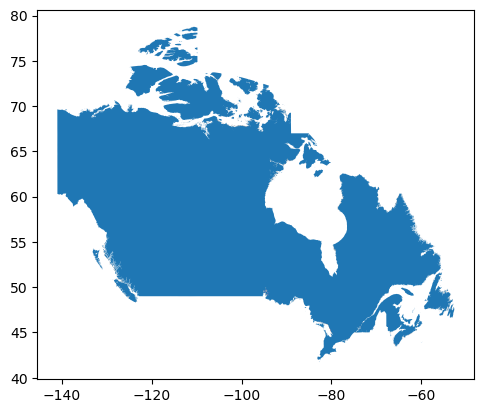

```python
# Plot the Canada boundary
%matplotlib inline
canadaBoundary.plot()
```

## Plotting the voronoi polygons

To plot the voronoi polygons, we will call the following modules and their functions.

```python
# Modules necessary for plotting the voronoi polygons
from geovoronoi.plotting import subplot_for_map, plot_voronoi_polys_with_points_in_area
from geovoronoi import voronoi_regions_from_coords, points_to_coords
```

As per our experience, plotting the voronoi polygons with a dataset that is as huge as having over 7000 hospitals will make the PC run forever. Therefore, we did some austerity measures. Select only those hospital facilites categorized as `general` and just pick a random sample of 100 of these hospitals. We want a dataset that Jupyter will quickly run over. We didn't have all day, and perhaps with a less powerful PC compared to yours, we decided to be ingenious.

```python
# Dataset of canada hospitals too huge
# Select only those 'source_facility_type' == `general`
canadaHospitalsGdf2 = canadaHospitalsGdf.loc[canadaHospitalsGdf['source_facility_type']=='general']

# Find length of canadaHospitalsGdf2
len(canadaHospitalsGdf2)
```

```
533
```

We will use the following code to take a sample of just 100 hospitals. Sorry Canadians!

```python
# Take sample of just 100 hospitals out of the over 500 rows
canadaHospitalsGdf3 = canadaHospitalsGdf2.sample(n=100)
print("\nLength of sampled dataset")
len(canadaHospitalsGdf3)
```

```
Length of sampled dataset
```

```
100
```

Before one draws voronoi polygons, the boundary shapefile --the `canadaBoundary` should be a union of the polygon. Secondly, the coordinates of the points have to be in a numpy array. Why all these requirements? Ask the makers of the voronoi modules, not us!

```python
# Make union of the polygon from canadaBoundary
boundaryShape = unary_union(canadaBoundary.geometry)
```

```python
# Convert canadaHospitalsGdf3 into an array of coordinates
coords = points_to_coords(canadaHospitalsGdf3.geometry)
```

```python
# calculate the Voronoi regions, cut them with the geographic area shape and assign the points to them
region_polys, region_pts = voronoi_regions_from_coords(coords, boundaryShape)
```

The following is the description of the `region_polys` and `region_pts` from the [voronoi module creators](https://pypi.org/project/geovoronoi/?utm_source=pocket_reader).

- **region_polys** - is a dict that maps Voronoi region IDs to shapely Polygon objects that represent the shape of the respective Voronoi region
- **region_pts** - is a dict that maps the same Voronoi region IDs as in region_polys to a list of indices into coords, i.e. these indices represent the points that belong to this Voronoi region. Usually, this is only a single point. However, in case of duplicate points (i.e. two or more points have exactly the same coordinates) all duplicate points are listed for the respective Voronoi region

To plot the voronoi polygons, we shall use the plotting tools specific for this endeavour. They are `subplot_for_map` and `plot_voronoi_polys_with_points_in_area`.

```python
# Plotting modules for voronoi polygns
from geovoronoi.plotting import subplot_for_map, plot_voronoi_polys_with_points_in_area
```

Now that we've loaded the requisite voronoi plotting modules, let's put them to work. The following code will now plot the voronoi plots for us.

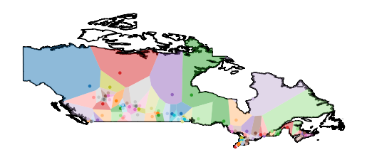

```python
# The format for plotting the voronoi polygons
fig, ax = subplot_for_map()
plot_voronoi_polys_with_points_in_area(ax, boundaryShape, region_polys, coords, region_pts)
plt.show()
```

From the above generated voronoi polygons, it is evident that the lower the number of hospitals, the larger their spatial area coverage.

# Conclusion

In this exercise, we created voronoi polygons by first loading the Canadian administrative shapefile and the hospital datasets. The hospital dataset was converted into a point geodataframe. Just like most geospatial operations, both the shapefile and the hospital dataset were transformed to a common CRS to enable overlaying. Thereafter, an array of coordinates was extracted from the points hospital geodataframe, which together with boundary of Canada, was used to create a voronoi diagram.